# Métodos Inferenciais em Pesquisas Legislativas - Lista de Exercícios

William Peixoto

> O código-fonte e os arquivos de dados estão também [no Github](https://github.com/wpeixoto/metodos-inferenciais/tree/master/Lista_01). Foi necessário modificar o encoding do script e dos dados para UTF-8 para a correta execução de certos comandos.

## Ambiente R

Baixe e instale o [R 3.4.4](https://cran.r-project.org/bin/windows/base/) e o [RStudio 1.1.442](https://www.rstudio.com/products/rstudio/download/) (Windows Vista/7/8/10).

Antes de resolver as questões a seguir, estude com atenção o Laboratório 1 da apostila.

## Questão 1

Acesse o repositório de dados http://vincentarelbundock.github.io/Rdatasets/datasets.html e localize a base de dados **Benefits**. Baixe o arquivo CSV e leia as informações do link DOC. Com base nas informações disponíveis, efetue as seguintes tarefas:

1. Leia o arquivo **Benefits.csv** com a função **read.csv** e atribua o resultado à variável **desempregados**. Mostre os 10 (dez) primeiros registros utilizando a função **head**. Done

```r
# lê o arquivo
desempregados = read.csv("Benefits.csv")

# apresenta os dez primeiros registros
head(desempregados, 10)
```

```
##     X stateur statemb state age tenure            joblost nwhite school12
## 1   1     4.5     167    42  49     21              other     no       no
## 2   2    10.5     251    55  26      2         slack_work     no       no
## 3   3     7.2     260    21  40     19              other     no      yes
## 4   4     5.8     245    56  51     17         slack_work    yes       no
## 5   5     6.5     125    58  33      1         slack_work     no      yes
## 6   6     7.5     188    11  51      3              other     no       no
## 7   7     5.8     166    93  30      5 position_abolished     no       no
## 8   8     5.8     214    84  26      3         slack_work     no       no
## 9   9     7.7     213    84  54     20              other     no       no
## 10 10     6.0     187    33  31      1         slack_work     no       no
##       sex bluecol smsa married dkids dykids yrdispl        rr head  ui
## 1    male     yes  yes      no    no     no       7 0.2906310  yes yes
## 2    male     yes  yes      no   yes    yes      10 0.5202020  yes  no
## 3  female     yes  yes     yes    no     no      10 0.4324895  yes yes
## 4  female     yes  yes     yes    no     no      10 0.5000000   no yes
## 5    male     yes  yes     yes   yes    yes       4 0.3906250  yes  no
## 6    male     yes  yes     yes    no     no      10 0.4822007  yes yes
## 7    male     yes  yes     yes   yes    yes       6 0.3340425  yes yes
## 8    male     yes  yes     yes   yes    yes       8 0.5109890  yes yes
## 9    male     yes  yes     yes    no     no       6 0.3556338  yes  no
## 10   male     yes  yes     yes    no     no       8 0.3732719  yes yes
```

2. Quantas observações (linhas) e quantas variáveis (colunas) contém o conjunto de dados lido? Done

```r
dim(desempregados)
```

```
## [1] 4877   19
```

```r
# linhas
linhas = nrow(desempregados)

# colunas
colunas = ncol(desempregados)
```

A quantidade de linhas é **4877** e a de colunas é **19**.

3. Altere, no script a seguir, os valores dos atributos **eval** e **include** para **TRUE** e escreva o código necessário para calcular as medidas de tendência central (média e mediana) e de dispersão (amplitude, amplitude interquartil, desvio padrão e coeficiente de variação) para a idade das pessoas que perderam o emprego nos Estados Unidos, no ano de 1972, nos estados cujos códigos são: 21, 44, 58, 82 e 94. Done

```
## [1] "Estado: 21   Média: 36.92   Mediana: 35.00   Amplitude: 14   Amp. Interquartil: 17.00   Devio Padrão: 11.04   Coeficiente de Variação:  0.30"
```

```
## [1] "Estado: 44   Média: 35.79   Mediana: 34.00   Amplitude: -18   Amp. Interquartil: 15.00   Devio Padrão: 10.29   Coeficiente de Variação:  0.29"
```

```
## [1] "Estado: 58   Média: 35.90   Mediana: 34.00   Amplitude: 1   Amp. Interquartil: 14.00   Devio Padrão: 10.17   Coeficiente de Variação:  0.28"
```

```
## [1] "Estado: 82   Média: 35.92   Mediana: 34.00   Amplitude: -26   Amp. Interquartil: 16.25   Devio Padrão: 10.62   Coeficiente de Variação:  0.30"
```

```
## [1] "Estado: 94   Média: 36.36   Mediana: 34.00   Amplitude: 3   Amp. Interquartil: 16.00   Devio Padrão: 10.77   Coeficiente de Variação:  0.30"
```

4. Utilizando a função **hist()** (consulte ?hist), plote o histograma das idades (1) considerando todos os respondentes e (2) considerando apenas os respondentes do estado 94. Alguma das distribuições parece ser normal? Comente. Done

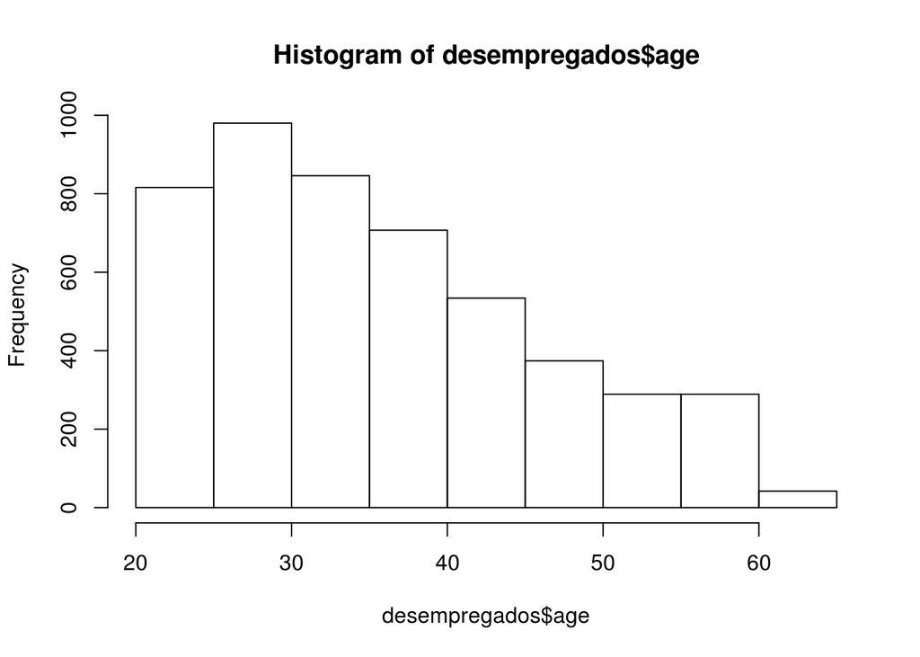

```r
# todos os estados
hist(desempregados$age)
```

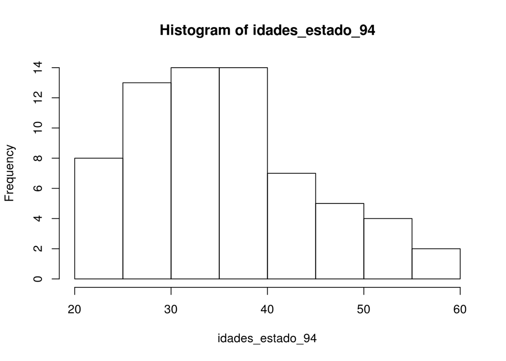

```r
media_idades = mean(desempregados$age)
mediana_idades = quantile(desempregados$age, probs = c(0.5))[[1]]
moda_idades = names(which.max(table(desempregados$age)))

# somente o estado 94
idades_estado_94 = desempregados$age[desempregados$state == 94]
hist(idades_estado_94)
```

```r
mediana_estado_94 = quantile(idades_estado_94, c(0.5))[[1]] # Mediana
media_idades_estado_94 = mean(idades_estado_94)
moda_idades_94 = names(which.max(table(idades_estado_94)))
```

[output not shown]

**Comentários**: Apesar de a média, moda e mediana das idades do estado 94 parecerem bem próximas, o histograma mostra uma curva bem diferente da normal.

Com intervalo de 5 anos, as distribuições não parecem ser normais. Os valores entre 20 e 35 anos são mais frequentes, mas a diversidade de idades vai de 20 a 61 anos, o que caracteriza uma assimetria positiva (a média é maior que a mediana)

Aumentar o número de intervalos (e consequentemente diminuir a amplitude de cada barra) não parece mudar radicalmente a forma da distribuição.

Há 2811 (57,63%) pessoas com idade inferior à média, e 2066 (42,36%) acima. Apesar da diferença entre a média e a mediana ser pequena (apenas 2 anos e pouco), considero que essa distribuição não parece normal.

Isso pode ser causado, por exemplo, por alguma restrição às idades das pessoas empregadas, que impede o aparecimento de qualquer ocorrência com idade menor que 20 anos.

5. Considerando o tempo que a pessoa permaneceu empregada (**tenure**), qual dos estados relaciondados (21, 44, 58, 82 e 94) proporciona maior establilidade no emprego?Done

```r
# todos os estados
osestados = desempregados[desempregados$state %in% c(21, 44, 58, 82, 94),] # Selecionar as LINHAS cujos estados sejam os listados
# Apenas os estados 21, 44, 58, 82, 94
print("Estado => Média de permanência")
```

```
## [1] "Estado => Média de permanência"
```

```r
for (est in c(21, 44, 58, 82, 94)) {
     print(paste(est, "==>", mean(osestados$tenure[osestados$state==est])))
}
```

```
## [1] "21 ==> 6.45581395348837"
## [1] "44 ==> 4.37254901960784"
## [1] "58 ==> 5.06779661016949"
## [1] "82 ==> 4.21818181818182"
## [1] "94 ==> 3.26865671641791"
```

A média de permanência do estado 21 é superior às dos demais estados.

```r
print("Anos de permanência ---->")
```

```
## [1] "Anos de permanência ---->"
```

```r
 table(as.factor(osestados$state),osestados$tenure)
```

```
##
##       1  2  3  4  5  6  7  8  9 10 11 12 13 14 15 16 17 19 20 21 24 28 29
##   21 41 39 27 18 17  4  3 10  6  8  4  6  2  5  6  1  5  1  0  1  2  1  1
##   44 16  8  7  2  4  5  0  1  2  2  2  0  1  0  0  0  0  0  0  0  0  0  0
##   58 13  9 10  6  4  1  2  3  3  1  0  2  0  0  1  1  1  0  1  1  0  0  0
##   82 12 16  5  5  6  0  2  2  1  2  0  3  0  0  0  0  0  0  0  0  0  1  0
##   94 17 18 14  7  1  3  2  0  1  2  0  0  1  0  0  0  1  0  0  0  0  0  0
##
##      30 31 32 35
##   21  2  2  1  2
##   44  0  1  0  0
##   58  0  0  0  0
##   82  0  0  0  0
##   94  0  0  0  0
```

Além disso, há mais observações de permanência superior a 15 anos no mesmo estado, o que permite estimar que nele permanência no emprego apresentou períodos maiores que nos outros.

## Questão 2

Efetuem os itens a seguir:

1. Verifique se o data.frame **desempregados** possui valores nulos (utilize a função **is.na**). Done

```
## [1] FALSE
```

O resultado de `any(is.na(desempregados))` é `FALSE`, o que significa que não há valores `NA` nessa variável.

2. Construa tabelas de frequência que ilustrem os seguintes cruzamentos de variáveis, considerando os estados 21, 44, 58, 82 e 94:
   1. estado (state) versus sexo (sex): dados absolutos Done
   2. estado (state) versus mais de 12 anos de escolaridade (school12): dados absolutos Done
   3. tipo do emprego perdido (joblost): dados absolutos, relativos e acumulados Done
   4. casado (married): dados absolutos, relativos e acumulados Done

```
## [1] "Estado x Sexo"
```

```
##
##      female male
##   21     55  160
##   44      9   42
##   58     18   41
##   82     13   42
##   94     12   55
```

```
## [1] "Estado x Anos de escolaridade (>12)"
```

```
##
##       no yes
##   21 176  39
##   44  31  20
##   58  49  10
##   82  43  12
##   94  44  23
```

```
## [1] "Motivos da perda do emprego (valores absolutos, relativos e acumulados)"
```

```
##      Motivo dispensa val.abs      val% acumul
## 1              other     181 40.492170    181
## 2 position_abolished      26  5.816555    207
## 3 seasonal_job_ended      32  7.158837    239
## 4         slack_work     208 46.532438    447
```

```
## [1] "Estado civil:"
```

```
##   Casados Valores absolutos Valores relativos Valores acumulados
## 1      no               163          36.46532                163
## 2     yes               284          63.53468                447
```

## Questão 3

Agora vamos trabalhar com um conjunto de dados bem maior.

1. Consulte o Repositório de Dados Eleitorais do TSE http://www.tse.jus.br/eleitor-e-eleicoes/estatisticas/repositorio-de-dados-eleitorais-1/repositorio-de-dados-eleitorais, acesse a área **Resultados**, selecione o ano **2016** e baixe o arquivo disponível no link **Votação nominal por município e zona (formato ZIP)**. Extraia do arquivo compactado **votacao_candidato_munzona_2016.zip**, para a pasta de trabalho definida no RStudio, o arquivo referente às votações em Santa Catarina **votacao_candidato_munzona_2016_SC.txt**. Consulte o dicionário de dados (arquivo LEIAME.pdf) e conheça a estrutura do arquivo descompactado. Done
2. Acesse a área **Candidatos**, selecione o ano **2016** e baixe o arquivo disponível no link **Candidatos (formato ZIP)**. Extraia do arquivo compactado **consulta_cand_2016.zip**, para a pasta de trabalho definida no RStudio, o arquivo referente aos candidatos de Santa Catarina **consulta_cand_2016_SC.txt**. Consulte o dicionário de dados (arquivo LEIAME.pdf) e conheça a estrutura do arquivo descompactado. Done
3. Altere, no script a seguir, os valores dos atributos **eval** e **include** para **TRUE** e execute o código instrução-a-instrução, tentando compreender cada passo. Done

```r
# TSE
rm(list = ls(all = TRUE))
# votação por zona eleitoral de SC
# votZona <- read.table("votacao_candidato_munzona_2016_SC.txt",sep=";")
votZona <- read.table("votacao_candidato_munzona_2016_SC.utf8.txt",sep=";")
names(votZona) <- c(
"DATA_GERACAO", "HORA_GERACAO", "ANO_ELEICAO",  "NUM_TURNO", "DESCRICAO_ELEICAO", "SIGLA_UF", "SIGLA_UE", "CODIGO_MUNICIPIO", "NOME_MUNICIPIO", "NUMERO_ZONA", "CODIGO_CARGO", "NUMERO_CAND",
"SQ_CANDIDATO", "NOME_CANDIDATO", "NOME_URNA_CANDIDATO", "DESCRICAO_CARGO", "COD_SIT_CAND_SUPERIOR", "DESC_SIT_CAND_SUPERIOR",
"CODIGO_SIT_CANDIDATO", "DESC_SIT_CANDIDATO", "CODIGO_SIT_CAND_TOT", "DESC_SIT_CAND_TOT", "NUMERO_PARTIDO", "SIGLA_PARTIDO",
"NOME_PARTIDO", "SEQUENCIAL_LEGENDA", "NOME_COLIGACAO", "COMPOSICAO_LEGENDA",
"TOTAL_VOTOS", "TRANSITO"
)
# filtra candidatos deferidos no primeiro turno
votZona <- votZona[(votZona$DESC_SIT_CANDIDATO == "DEFERIDO"
      | votZona$DESC_SIT_CANDIDATO == "DEFERIDO COM RECURSO")
      & votZona$NUM_TURNO == 1, ]
# cria um identificador para o candidato combinando
# os campos SIGLA_UE e NUMERO_CAND
votZona$ID_CANDIDATO <-
       as.numeric(paste0(as.character(votZona$SIGLA_UE),
                         as.character(votZona$NUMERO_CAND)))
# mantém apenas os campos de interesse
votZona <- votZona[ , c(
          "CODIGO_MUNICIPIO", "NOME_MUNICIPIO",
          "NUMERO_ZONA", "ID_CANDIDATO",
          "NOME_CANDIDATO", "NOME_URNA_CANDIDATO",
          "DESCRICAO_CARGO", "NUMERO_PARTIDO",
          "SIGLA_PARTIDO", "NOME_PARTIDO",
          "NOME_COLIGACAO", "COMPOSICAO_LEGENDA",
          "TOTAL_VOTOS", "TRANSITO"
         )
       ]

# candidatos SC
cand <- read.table("consulta_cand_2016_SC.txt",sep=";")
names(cand)[c(4,7,12,13,11,16,17, 29,30,31)] <-
        c("NUM_TURNO","SIGLA_UE","SEQUENCIAL_CANDIDATO",
          "NUMERO_CANDIDATO", "NOME_CANDIDATO",
          "COD_SITUACAO_CANDIDATURA",
    "DES_SITUACAO_CANDIDATURA",
    "IDADE_DATA_ELEICAO",
    "CODIGO_SEXO",
    "DESCRICAO_SEXO"
   )
# cria um identificador para o candidato combinando
# os campos SIGLA_UE e NUMERO_CANDIDATO
cand$ID_CANDIDATO <-
     as.numeric(paste0(as.character(cand$SIGLA_UE),
                       as.character(cand$NUMERO_CANDIDATO)))
# filtra candidatos deferidos no primeiro turno
# e mantém apenas os campos de interesse
cand <- cand[(cand$DES_SITUACAO_CANDIDATURA == "DEFERIDO" |
   cand$DES_SITUACAO_CANDIDATURA == "DEFERIDO COM RECURSO") &
   cand$NUM_TURNO == 1, c(47,11,29,31)]
#  combina os dois data.frames
votZona <- merge(votZona, cand)
```

4. Informe as dimensões do conjunto de dados votZona resultante.

```r
# linhas
nrow(votZona)
```

```
## [1] 18438
```

```r
# colunas
ncol(votZona)
```

```
## [1] 16
```

5. Investigue as formas de extração de subconjuntos de dados a partir de um conjunto maior (consulte [Quick-R](https://www.statmethods.net/management/subset.html) e **?subset**).
6. A partir do conjunto de dados **votZona** resultante, informe a quantidade de municípios em SC onde ocorreram as eleições de 2016 e a quantidade de zonas eleitorais. Done

```r
# qtd municípios
municipios = length(table(votZona$CODIGO_MUNICIPIO))

# qtd zonas eleitorais
zonas = length(table(votZona$NUMERO_ZONA))
```

Há 295 municípios e 105 zonas eleitorais relatados no arquivo `votacao_candidato_munzona_2016_SC.txt`.

7. Construa uma tabela contendo os campos NOME_URNA_CANDIDATO, DESCRICAO_CARGO, NOME_MUNICIPIO, TOTAL_VOTOS e PERCENTUAL_VOTOS para os **dez** candidatos a cargo de vereador mais votados na cidade de SANTIAGO DO SUL. A tabela deve ser apresentada na ordem decrescente do total de votos recebidos pelos candidatos. Done

```r
SANT = votZona[votZona$NOME_MUNICIPIO == 'SANTIAGO DO SUL',]  # Apenas o município solicitado
SANT = SANT[SANT$DESCRICAO_CARGO == 'VEREADOR',]  # Apenas vereadores
SANT = SANT[,c('NOME_URNA_CANDIDATO', 'DESCRICAO_CARGO', 'NOME_MUNICIPIO', 'TOTAL_VOTOS')]  # desprezar outras colunas
TOT_VOTOS = sum(SANT$TOTAL_VOTOS)  # Calcular total de votos
SANT$PERCENTUAL_VOTOS = SANT$TOTAL_VOTOS/TOT_VOTOS*100  # Nova coluna com percentual de votos

# Exibir tabela
head(SANT[order(SANT$TOTAL_VOTOS, decreasing = T),], 10)
```

```
##      NOME_URNA_CANDIDATO DESCRICAO_CARGO  NOME_MUNICIPIO TOTAL_VOTOS
## 7666            MARISSOL        VEREADOR SANTIAGO DO SUL          97
## 7671        ADE CASANOVA        VEREADOR SANTIAGO DO SUL          92
## 7658       ALEX VERONESE        VEREADOR SANTIAGO DO SUL          88
## 7654               ODAIR        VEREADOR SANTIAGO DO SUL          85
## 7659         NILSO SIMON        VEREADOR SANTIAGO DO SUL          85
## 7653         ARNALDO ZAT        VEREADOR SANTIAGO DO SUL          79
## 7651        DANIEL RISSI        VEREADOR SANTIAGO DO SUL          71
## 7655   VALDECIR DA SILVA        VEREADOR SANTIAGO DO SUL          70
## 7664   VANDERLEI SARETTO        VEREADOR SANTIAGO DO SUL          70
## 7667       PEDRO PACAZZA        VEREADOR SANTIAGO DO SUL          69
##      PERCENTUAL_VOTOS
## 7666         7.531056
## 7671         7.142857
## 7658         6.832298
## 7654         6.599379
## 7659         6.599379
## 7653         6.133540
## 7651         5.512422
## 7655         5.434783
## 7664         5.434783
## 7667         5.357143
```

```r
answer_style="background-color:#a9e970;border-color:navy;padding:5px"
```

Acredito que seria melhor omitir as colunas DESCRICAO_CARGO e NOME_MUNICIPIO, que não acrescentam valor porque o exercício especificou um valor fixo para elas.

8. Plote um histograma do quantitativo de votos para VEREADOR em todo o estado de Santa Catarina, considerando os casos em que o total de votos recebidos foi menor ou igual a 1000. Done

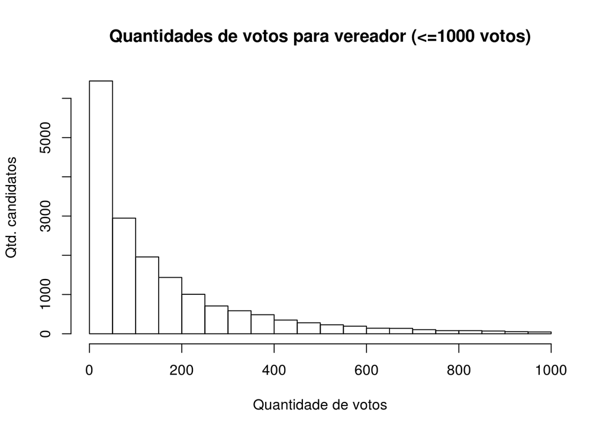

```r
VEREADORES = votZona[votZona$DESCRICAO_CARGO == 'VEREADOR', ]  # apenas vereadores
hist(VEREADORES$TOTAL_VOTOS[VEREADORES$TOTAL_VOTOS <= 1000],
     main = "Quantidades de votos para vereador (<=1000 votos)",
     xlab = "Quantidade de votos",
     ylab = "Qtd. candidatos")
```

```r
library(knitr)
mais_novos = votZona[votZona$IDADE_DATA_ELEICAO == min(votZona$IDADE_DATA_ELEICAO), ]
mais_novos = mais_novos[, c('NOME_CANDIDATO', 'IDADE_DATA_ELEICAO', 'DESCRICAO_CARGO', 'NOME_MUNICIPIO', 'TOTAL_VOTOS')]  # Apenas algumas colunas
names(mais_novos) = c('NOME', 'IDADE', 'CARGO', 'MUNICIPIO', 'VOTOS')  # Renomear campos

kable(mais_novos, format='pandoc')
```

|  | NOME | IDADE | CARGO | MUNICIPIO | VOTOS |
| --- | --- | --- | --- | --- | --- |
| 437 | ELIZANDRA APARECIDA DE SOUZA | 18 | VEREADOR | VITOR MEIRELES | 5 |
| 637 | KATHELEEN PEGORARO | 18 | VEREADOR | ANITA GARIBALDI | 53 |
| 3596 | JAQUELINE DALLAGO PEREIRA | 18 | VEREADOR | CAMBORIÚ | 11 |
| 3857 | KARLA MARIA NUNES DE ASSIS | 18 | VEREADOR | CAMPO BELO DO SUL | 22 |
| 4345 | JONATHAN ALENCAR DOS SANTOS | 18 | VEREADOR | SÃO MIGUEL DA BOA VISTA | 18 |
| 5193 | MARCOS ANDRE VIEIRA MELLER | 18 | VEREADOR | CRICIÚMA | 393 |
| 5194 | MARCOS ANDRE VIEIRA MELLER | 18 | VEREADOR | CRICIÚMA | 538 |
| 5195 | MARCOS ANDRE VIEIRA MELLER | 18 | VEREADOR | CRICIÚMA | 403 |
| 5736 | RAFAEL LIMA DA COSTA | 18 | VEREADOR | SANGÃO | 129 |
| 7528 | KEILA NAYARA DA SILVA | 18 | VEREADOR | GASPAR | 9 |
| 8607 | RAYANE DE CARVALHO FLOR | 18 | VEREADOR | IMBITUBA | 1 |
| 9132 | IANDEYARA LOUISE FUNEZ | 18 | VEREADOR | ITÁ | 22 |
| 9958 | SCHEILA BEATRIZ LOCH | 18 | VEREADOR | PRINCESA | 14 |
| 13302 | LUANA CORDEIRO DE LIMA | 18 | VEREADOR | MAFRA | 1 |
| 13458 | MATHEUS ANTUNES | 18 | VEREADOR | MARAVILHA | 215 |
| 13551 | GREICE GRIBOSKI | 18 | VEREADOR | MASSARANDUBA | 60 |
| 13586 | KARINE APARECIDA CRIMINANCIO SANTOS | 18 | VEREADOR | MATOS COSTA | 41 |
| 13753 | JESSICA BEZERRA MARTINS | 18 | VEREADOR | MORRO DA FUMAÇA | 13 |
| 14879 | SUELEN ANITA NUNES | 18 | VEREADOR | PONTE SERRADA | 23 |
| 15903 | JULIANA SILVA COELHO | 18 | VEREADOR | SANTO AMARO DA IMPERATRIZ | 2 |
| 16158 | TAINAH KAUANA LARA RIBEIRO | 18 | VEREADOR | SÃO FRANCISCO DO SUL | 163 |
| 18161 | ROGERIO ALVES DE LIMA | 18 | VEREADOR | XAXIM | 30 |

10. Qual a razão entre o quantitativo de votos para o cargo de VEREADOR recebido por mulheres e o recebido por homens na cidade de CAMBORIÚ. Done

```r
camb = votZona[votZona$NOME_MUNICIPIO == 'CAMBORIÚ',]  # Apenas município de Camboriú
camb = camb[camb$DESCRICAO_CARGO == 'VEREADOR', ]  # Apenas candidatos a vereador
votos_para_mulheres = sum(camb$TOTAL_VOTOS[camb$DESCRICAO_SEXO == 'FEMININO'])
votos_para_homens = sum(camb$TOTAL_VOTOS[camb$DESCRICAO_SEXO == 'MASCULINO'])

votos_para_mulheres / votos_para_homens
```

```
## [1] 0.2394133
```

11. Considerando o quantitativo total de votos para os cargos de VEREADOR e PREFEITO, identifique qual a menor zona eleitoral de SC e qual (quais) município (municípios) é (são) abrangido(s) por essa zona. Done

```r
#conta_zonas = votZona[,c("DESCRICAO_CARGO", "CODIGO_MUNICIPIO", "NUMERO_ZONA", "TOTAL_VOTOS")]
conta_zonas = votZona[,c("DESCRICAO_CARGO", "NUMERO_ZONA", "TOTAL_VOTOS")]
conta_zonas$NUMERO_ZONA = as.factor(conta_zonas$NUMERO_ZONA)
attach(conta_zonas)
soma_zonas = aggregate(TOTAL_VOTOS ~NUMERO_ZONA, conta_zonas, sum)
detach(conta_zonas)
menos_votos = soma_zonas[order(soma_zonas$TOTAL_VOTOS, decreasing = T), ]
head(menos_votos)
```

```
##     NUMERO_ZONA TOTAL_VOTOS
## 105         105      138008
## 24           24      137500
## 100         100      131555
## 76           76      123939
## 16           16      116402
## 19           19      115944
```

```r
menor_zona = menos_votos[1,]
# menor_zona


conta_municipios = votZona[,c("DESCRICAO_CARGO", "CODIGO_MUNICIPIO", "TOTAL_VOTOS")]
attach(conta_municipios)
soma_municipios = aggregate(TOTAL_VOTOS ~CODIGO_MUNICIPIO, conta_municipios, sum)
detach(conta_municipios)
muni_menos_votos = soma_municipios[order(soma_zonas$TOTAL_VOTOS, decreasing = T), ]
head(muni_menos_votos)
```

```
##     CODIGO_MUNICIPIO TOTAL_VOTOS
## 105            81043        5268
## 24             80233        8225
## 100            80993        5326
## 76             80756       25259
## 16             80152        8377
## 19             80187        6720
```

```r
menor_municipio = muni_menos_votos[1, ]

tab_mun_zona = unique(votZona[c('NOME_MUNICIPIO', 'CODIGO_MUNICIPIO', 'NUMERO_ZONA')])
menor_municipio$NOME_MUNICIPIO = tab_mun_zona$NOME_MUNICIPIO[tab_mun_zona$CODIGO_MUNICIPIO == menor_municipio$CODIGO_MUNICIPIO]

# municipios_zona_menor = tab_mun_zona[tab_mun_zona$NUMERO_ZONA == 105, ]
municipios_zona_menor = tab_mun_zona[tab_mun_zona$NUMERO_ZONA == menor_zona[[1]], ]
```

|  | NOME_MUNICIPIO | CODIGO_MUNICIPIO | NUMERO_ZONA |
| --- | --- | --- | --- |
| 7403 | GARUVA | 81159 | 105 |
| 10006 | ITAPOÁ | 81663 | 105 |
| 10683 | JOINVILLE | 81795 | 105 |

# DATA DE ENTREGA: 17/05/2018

## Enviar o arquivo “Rmd” para o email fabiano.schwartz@camara.leg.br